# Working with Factors

Ted Laderas

5/18/2017

## R Markdown

In this section, we’ll learn some skills about manipulating factor (categorical) data.

We’ll do this by making a bar plot and progressively making it more complex.

## Reviewing Factors

Factors are how R represents categorical data.

There are two kinds of factors:

- `factor` - used for *nominal* data (“Ducks”,“Cats”,“Dogs”)
- `ordered`- used for *ordinal* data (“10-30”,“31-40”,“41-60”)

We’ll manipulate our barplot and add more information using factors.

```r
##make our table of pets
pets <- data.frame(id=c('C1','C2','D1','D4','D8', 'C4', 'D5', 'C10'),
                names=factor(c("Morris", "Morris", "Fido", "Mr Bowser", "Fido", "Lady Sheba", "Hubert", "Apples")),
                weights=c(6,7,15,20,40, 10, 60, 17),
                animal=factor(c("cat", "cat", "dog", "dog", "dog", "cat", "dog", "cat")),
                ##because it's an ordered category, we have to specify
                ##order as the levels argument
                ageCategory= ordered(c("0-2", "5-8", "5-8", "3-4", "3-4", "5-8", "0-2", "5-8"),
                                       levels=c("0-2", "3-4", "5-8")),
                shotsCurrent=c("No", "Yes", NA, "No", "Yes", "No", "No", "Yes"))

pets
```

```
##    id      names weights animal ageCategory shotsCurrent
## 1  C1     Morris       6    cat         0-2           No
## 2  C2     Morris       7    cat         5-8          Yes
## 3  D1       Fido      15    dog         5-8         <NA>
## 4  D4  Mr Bowser      20    dog         3-4           No
## 5  D8       Fido      40    dog         3-4          Yes
## 6  C4 Lady Sheba      10    cat         5-8           No
## 7  D5     Hubert      60    dog         0-2           No
## 8 C10     Apples      17    cat         5-8          Yes
```

## Let’s build a bar plot

Let’s plot the weights for each pet.

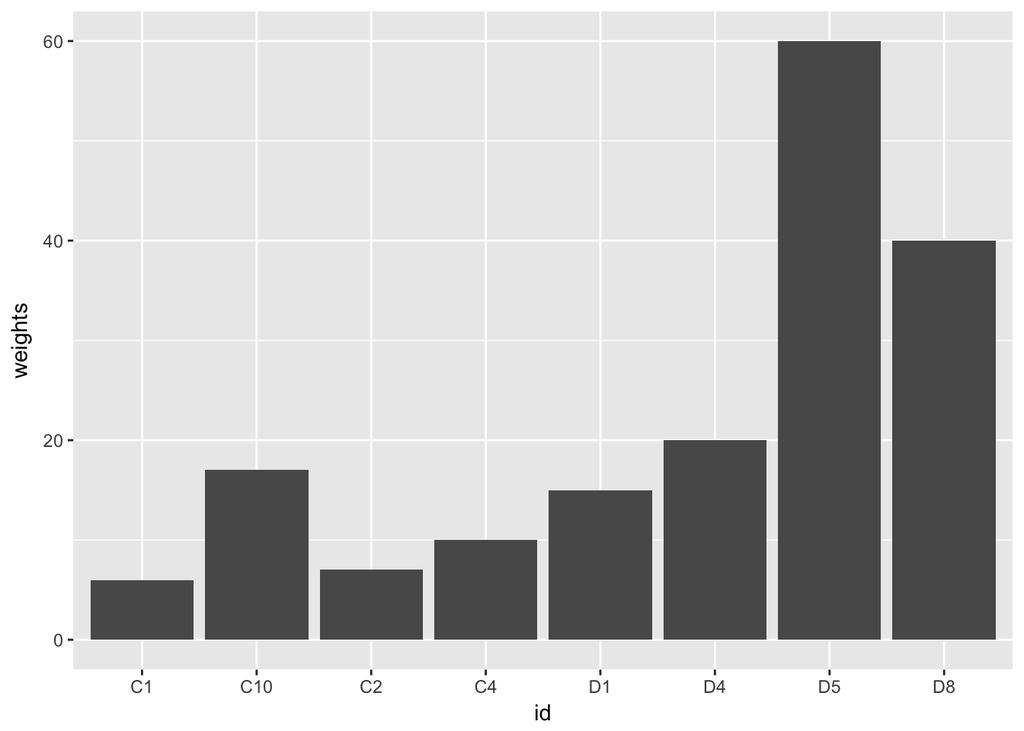

```r
ggplot(data=pets, aes(x=id,y=weights)) + geom_bar(stat="identity")
```

## What about counting?

The `geom_bar()` default is to count the number with each factor. Note that you don’t map to a y-aesthetic here, because the y values are the counts.

Given this dataset, we want to ask how many pets have the same name.

Map another variable to `fill` (try both `weight` and `animal`). Are the results what you expected?

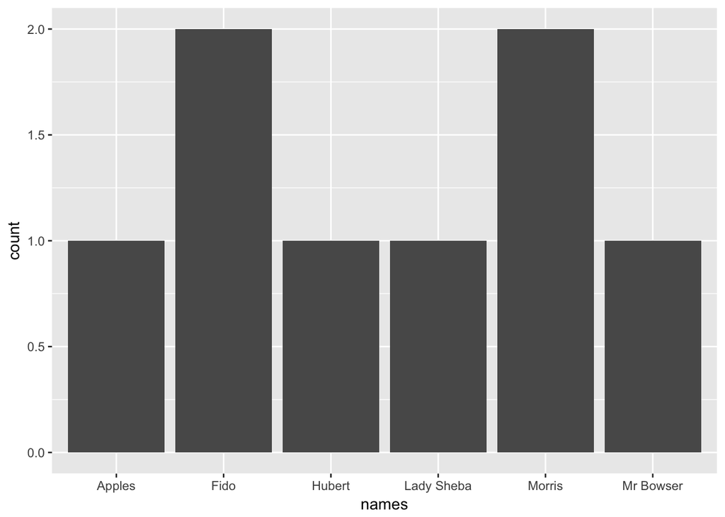

```r
ggplot(pets, aes(x=names)) + geom_bar()
```

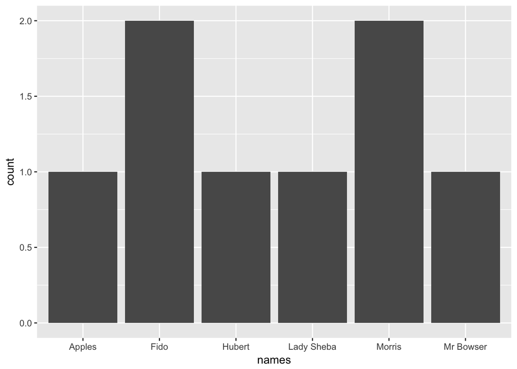

```r
ggplot(pets, aes(x=names)) + geom_bar()
```

## Faceting

Say you have another `factor` variable and you want to stratify the plots based on that.

You can do that by supplying the name of that variable as a facet.

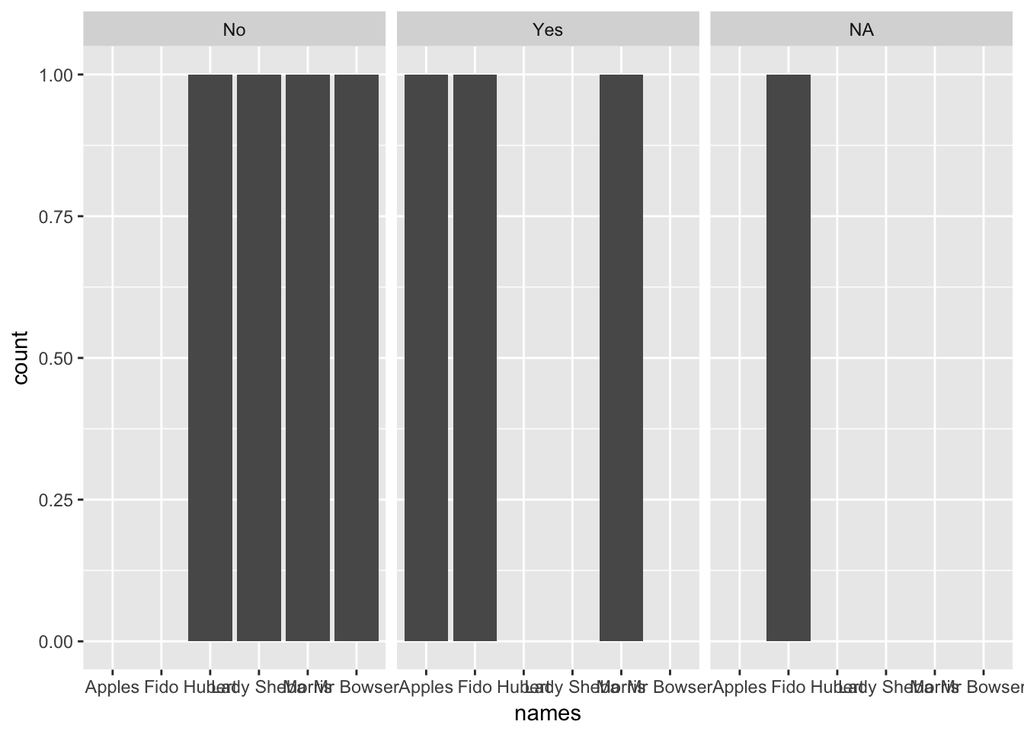

```r
ggplot(pets, aes(x=names)) + geom_bar() + facet_wrap(facets=~shotsCurrent)
```

You might notice that there are blank spots for the categories in each facet. We can restrict factors in each by using `scale="free"` argument in `facet_wrap()`.

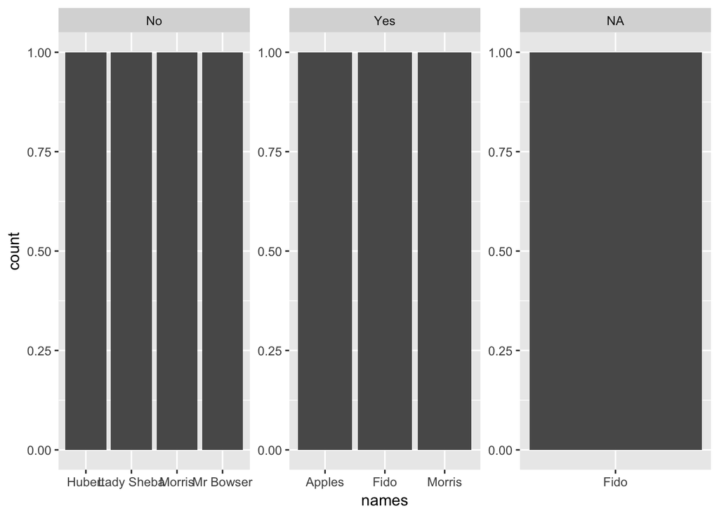

```r
ggplot(pets, aes(x=names)) + geom_bar() + facet_wrap(facets=~shotsCurrent, scale="free")
```

## Stacked Bars

Let’s see how many of each animal got shots. We can do this by mapping shots to `fill`.

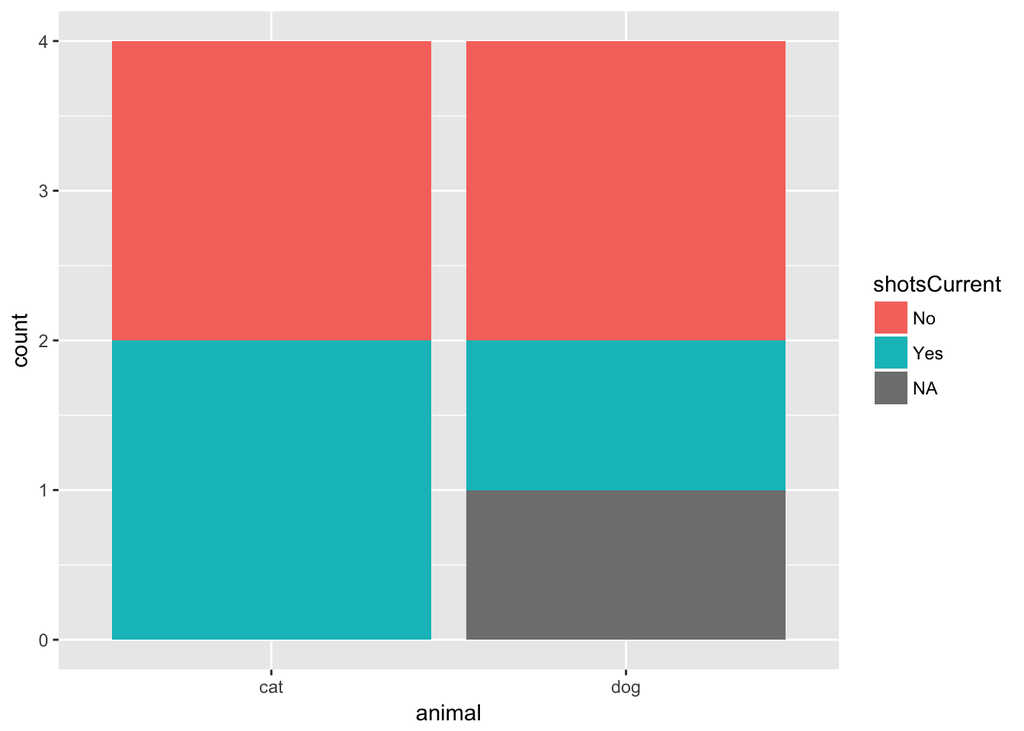

```r
ggplot(pets, aes(x=animal,fill=shotsCurrent)) + geom_bar()
```

## Dodge those bars!

Instead of stacking, we can also dodge the bars.

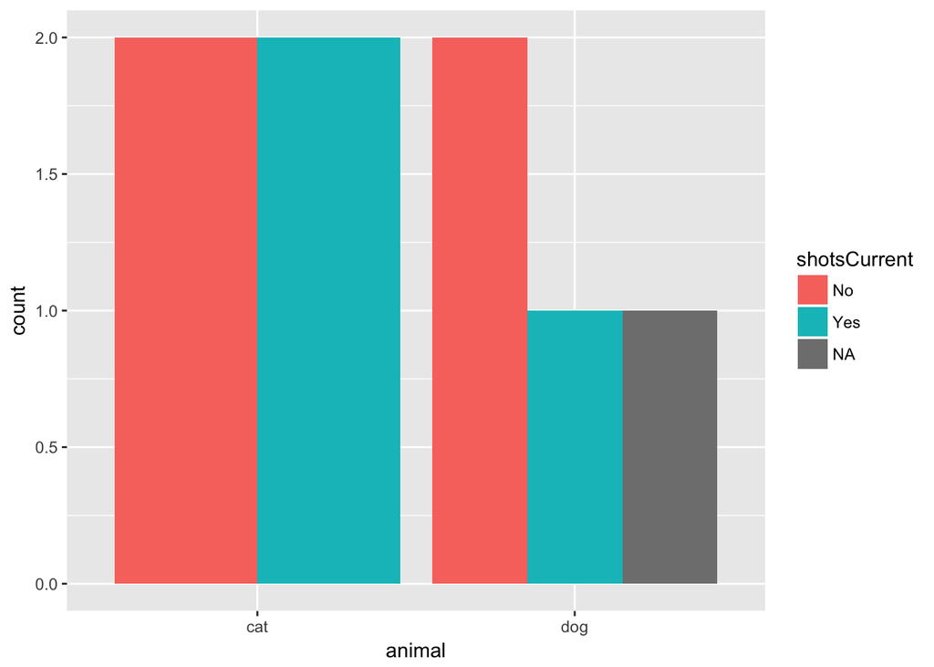

```r
ggplot(pets, aes(x=animal,fill=shotsCurrent)) + geom_bar(position="dodge")
```

## Boxplots

Boxplots allow us to assess distributions of a continuous variable conditioned on categorical variables.

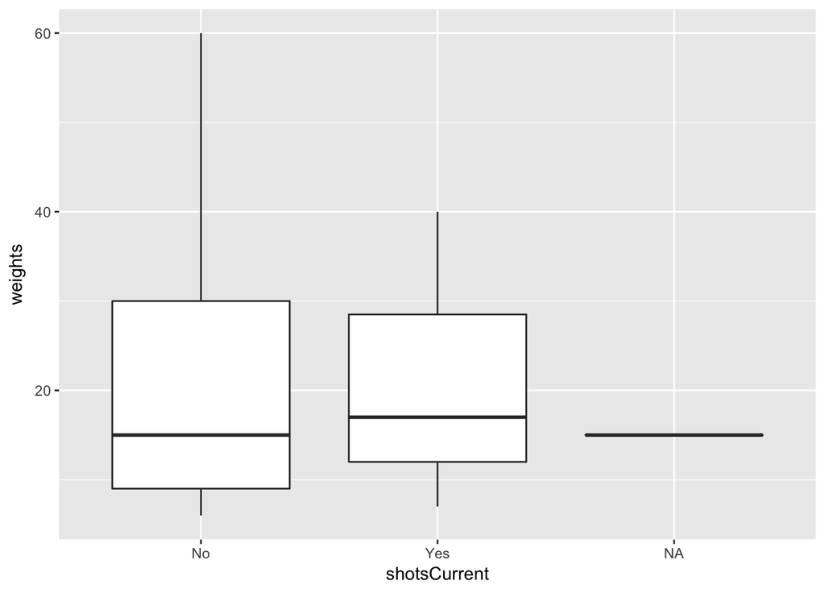

```r
ggplot(pets, aes(x=shotsCurrent, y=weights)) + geom_boxplot()
```

## Violin Plots

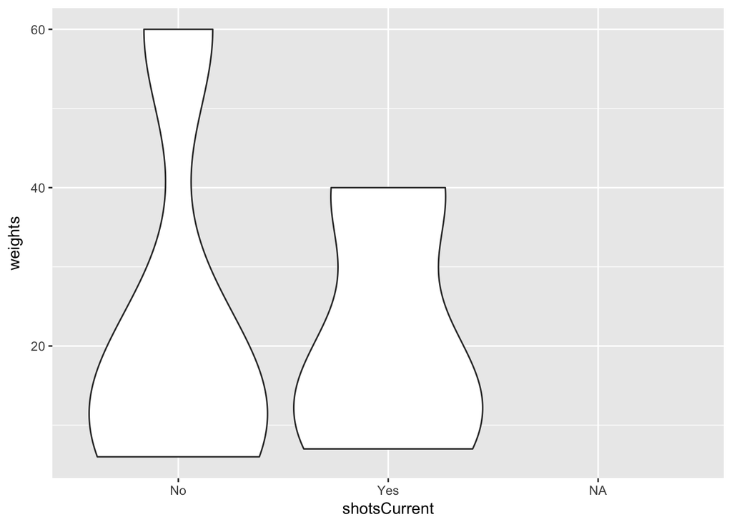

```r
ggplot(pets, aes(x=shotsCurrent, y=weights)) + geom_violin()
```

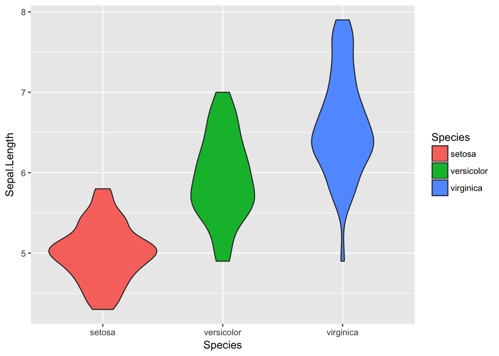

```r
data(iris)

ggplot(iris, aes(x=Species, y=Sepal.Length, fill=Species)) + geom_violin()
```

[output not shown]